### TEP IA

**Notebook EDA**

# Análisis Exploratorio del Dataset de Iris

## Objetivo del Proyecto

El objetivo de este análisis es explorar el famoso dataset de sklearn para entender las características de las diferentes especies de flores. Buscaremos identificar patrones en las medidas de los pétalos y sépalos que nos permitan distinguir entre las tres especies: **setosa**, **versicolor** y **virginica**. Realizaremos un resumen estadístico y visualizaciones clave para lograr este entendimiento.

## Visualizaciones

A continuación, presentamos dos visualizaciones para explorar las relaciones entre las variables y las especies.

1. **Gráfico de dispersión (Scatter Plot):** Muestra la relación entre la longitud y el ancho de los sépalos, coloreados por especie. Esto nos ayudará a ver si hay agrupaciones visuales.
2. **Gráfico de violín (Violin Plot):** Muestra la distribución de la longitud de los pétalos para cada especie, ofreciendo una visión de la densidad y el rango de valores.

## Limpieza y Transformación de Datos

El dataset de Iris ya está notablemente limpio y no requiere una limpieza exhaustiva. Sin embargo, hemos realizado una transformación clave para facilitar el análisis:

- **Transformación de la columna `target`:** La columna numérica original `target` ha sido transformada a la columna `species`, que contiene los nombres de las especies (`setosa`, `versicolor`, `virginica`). Esto hace que el análisis sea más intuitivo y las visualizaciones más informativas. No se detectaron valores nulos o atípicos significativos que requieran una limpieza adicional.

```
Resumen estadístico del dataset:
       sepal length (cm)  sepal width (cm)  petal length (cm)  \
count         150.000000        150.000000         150.000000
mean            5.843333          3.057333           3.758000
std             0.828066          0.435866           1.765298
min             4.300000          2.000000           1.000000
25%             5.100000          2.800000           1.600000
50%             5.800000          3.000000           4.350000
75%             6.400000          3.300000           5.100000
max             7.900000          4.400000           6.900000

       petal width (cm)
count        150.000000
mean           1.199333
std            0.762238
min            0.100000
25%            0.300000
50%            1.300000
75%            1.800000
max            2.500000

Primeras 5 filas del dataset:
   sepal length (cm)  sepal width (cm)  petal length (cm)  petal width (cm)  \
0                5.1               3.5                1.4               0.2
1                4.9               3.0                1.4               0.2
2                4.7               3.2                1.3               0.2
3                4.6               3.1                1.5               0.2
4                5.0               3.6                1.4               0.2

  species
0  setosa
1  setosa
2  setosa
3  setosa
4  setosa
```

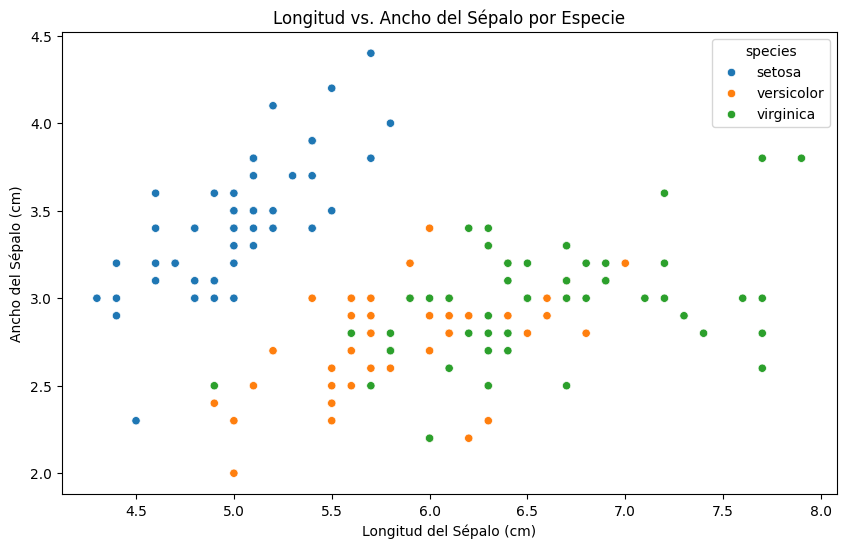

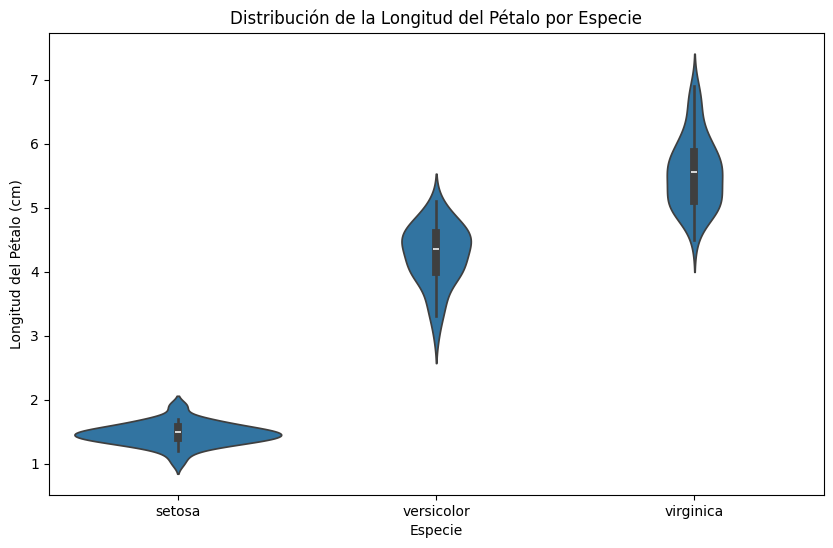

```python
import pandas as pd
import seaborn as sns
import matplotlib.pyplot as plt
from sklearn.datasets import load_iris

# Cargar el dataset de Iris
iris = load_iris()
df = pd.DataFrame(data=iris.data, columns=iris.feature_names)
df['species'] = iris.target_names[iris.target]

# Resumen estadístico
print("Resumen estadístico del dataset:")
print(df.describe())

# Ver las primeras 5 filas
print("\nPrimeras 5 filas del dataset:")
print(df.head())

# Visualización 1: Scatter plot
plt.figure(figsize=(10, 6))
sns.scatterplot(x='sepal length (cm)', y='sepal width (cm)', hue='species', data=df)
plt.title('Longitud vs. Ancho del Sépalo por Especie')
plt.xlabel('Longitud del Sépalo (cm)')
plt.ylabel('Ancho del Sépalo (cm)')
plt.show()

# Visualización 2: Violin plot
plt.figure(figsize=(10, 6))
sns.violinplot(x='species', y='petal length (cm)', data=df)
plt.title('Distribución de la Longitud del Pétalo por Especie')
plt.xlabel('Especie')
plt.ylabel('Longitud del Pétalo (cm)')
plt.show()
```